# Time series graphics

## Tsibble

Tsibble example

```r
y <- tsibble(
  Year = 2015:2019,
  Observation = c(123, 39, 78, 52, 110),
  index = Year
)
y
```

```
## # A tsibble: 5 x 2 [1Y]
##    Year Observation
##   <int>       <dbl>
## 1  2015         123
## 2  2016          39
## 3  2017          78
## 4  2018          52
## 5  2019         110
```

Olympic running dataframe

```r
kable(olympic_running[1:kable_length, ])
```

| Year | Length | Sex | Time |
| --- | --- | --- | --- |
| 1896 | 100 | men | 12.0 |
| 1900 | 100 | men | 11.0 |
| 1904 | 100 | men | 11.0 |
| 1908 | 100 | men | 10.8 |
| 1912 | 100 | men | 10.8 |

```r
olympic_running %>% distinct(Sex, Length) %>% kable()
```

| Length | Sex |
| --- | --- |
| 100 | men |
| 100 | women |
| 200 | men |
| 200 | women |
| 400 | men |
| 400 | women |
| 800 | men |
| 800 | women |
| 1500 | men |
| 1500 | women |
| 5000 | men |
| 5000 | women |
| 10000 | men |
| 10000 | women |

Some training on dplyr

```r
kable(PBS[1:kable_length, ])
```

| Month | Concession | Type | ATC1 | ATC1_desc | ATC2 | ATC2_desc | Scripts | Cost |
| --- | --- | --- | --- | --- | --- | --- | --- | --- |
| 1991 Jul | Concessional | Co-payments | A | Alimentary tract and metabolism | A01 | STOMATOLOGICAL PREPARATIONS | 18228 | 67877 |
| 1991 Aug | Concessional | Co-payments | A | Alimentary tract and metabolism | A01 | STOMATOLOGICAL PREPARATIONS | 15327 | 57011 |
| 1991 Sep | Concessional | Co-payments | A | Alimentary tract and metabolism | A01 | STOMATOLOGICAL PREPARATIONS | 14775 | 55020 |
| 1991 Oct | Concessional | Co-payments | A | Alimentary tract and metabolism | A01 | STOMATOLOGICAL PREPARATIONS | 15380 | 57222 |
| 1991 Nov | Concessional | Co-payments | A | Alimentary tract and metabolism | A01 | STOMATOLOGICAL PREPARATIONS | 14371 | 52120 |

```r
PBS %>%
  filter(ATC2 == "A10") %>%
  select(Month, Concession, Type, Cost) %>%
  slice_head(n = 5) %>%
  kable()
```

| Month | Concession | Type | Cost |
| --- | --- | --- | --- |
| 1991 Jul | Concessional | Co-payments | 2092878 |
| 1991 Aug | Concessional | Co-payments | 1795733 |
| 1991 Sep | Concessional | Co-payments | 1777231 |
| 1991 Oct | Concessional | Co-payments | 1848507 |
| 1991 Nov | Concessional | Co-payments | 1686458 |

```r
# Total cost by monthyear
PBS %>%
  filter(ATC2 == "A10") %>%
  select(Month, Concession, Type, Cost) %>%
  summarise(TotalCost = sum(Cost))
```

```
## # A tsibble: 204 x 2 [1M]
##       Month TotalCost
##       <mth>     <dbl>
##  1 1991 Jul   3526591
##  2 1991 Aug   3180891
##  3 1991 Sep   3252221
##  4 1991 Oct   3611003
##  5 1991 Nov   3565869
##  6 1991 Dec   4306371
##  7 1992 Jan   5088335
##  8 1992 Feb   2814520
##  9 1992 Mar   2985811
## 10 1992 Apr   3204780
## # ... with 194 more rows
```

```r
# Total cost by monthyear (M dollars)
PBS %>%
  filter(ATC2 == "A10") %>%
  select(Month, Concession, Type, Cost) %>%
  summarise(TotalCost = sum(Cost)) %>%
  mutate(TotalCost = TotalCost / 1e6) -> a10
a10
```

```
## # A tsibble: 204 x 2 [1M]
##       Month TotalCost
##       <mth>     <dbl>
##  1 1991 Jul      3.53
##  2 1991 Aug      3.18
##  3 1991 Sep      3.25
##  4 1991 Oct      3.61
##  5 1991 Nov      3.57
##  6 1991 Dec      4.31
##  7 1992 Jan      5.09
##  8 1992 Feb      2.81
##  9 1992 Mar      2.99
## 10 1992 Apr      3.20
## # ... with 194 more rows
```

Importing a csv

```r
prison <- readr::read_csv("https://OTexts.com/fpp3/extrafiles/prison_population.csv") # nolint
prison
```

```
## # A tibble: 3,072 x 6
##    Date       State Gender Legal     Indigenous Count
##    <date>     <chr> <chr>  <chr>     <chr>      <dbl>
##  1 2005-03-01 ACT   Female Remanded  ATSI           0
##  2 2005-03-01 ACT   Female Remanded  Non-ATSI       2
##  3 2005-03-01 ACT   Female Sentenced ATSI           0
##  4 2005-03-01 ACT   Female Sentenced Non-ATSI       5
##  5 2005-03-01 ACT   Male   Remanded  ATSI           7
##  6 2005-03-01 ACT   Male   Remanded  Non-ATSI      58
##  7 2005-03-01 ACT   Male   Sentenced ATSI           5
##  8 2005-03-01 ACT   Male   Sentenced Non-ATSI     101
##  9 2005-03-01 NSW   Female Remanded  ATSI          51
## 10 2005-03-01 NSW   Female Remanded  Non-ATSI     131
## # ... with 3,062 more rows
```

```r
prison <- prison %>%
  mutate(Quarter = yearquarter(Date)) %>%
  select(-Date) %>%
  as_tsibble(key = c(State, Gender, Legal, Indigenous),
             index = Quarter)

prison
```

```
## # A tsibble: 3,072 x 6 [1Q]
## # Key:       State, Gender, Legal, Indigenous [64]
##    State Gender Legal    Indigenous Count Quarter
##    <chr> <chr>  <chr>    <chr>      <dbl>   <qtr>
##  1 ACT   Female Remanded ATSI           0 2005 Q1
##  2 ACT   Female Remanded ATSI           1 2005 Q2
##  3 ACT   Female Remanded ATSI           0 2005 Q3
##  4 ACT   Female Remanded ATSI           0 2005 Q4
##  5 ACT   Female Remanded ATSI           1 2006 Q1
##  6 ACT   Female Remanded ATSI           1 2006 Q2
##  7 ACT   Female Remanded ATSI           1 2006 Q3
##  8 ACT   Female Remanded ATSI           0 2006 Q4
##  9 ACT   Female Remanded ATSI           0 2007 Q1
## 10 ACT   Female Remanded ATSI           1 2007 Q2
## # ... with 3,062 more rows
```

## Time plots

Ansett dataframe

```r
ansett <- ansett
ansett
```

```
## # A tsibble: 7,407 x 4 [1W]
## # Key:       Airports, Class [30]
##        Week Airports Class    Passengers
##      <week> <chr>    <chr>         <dbl>
##  1 1989 W28 ADL-PER  Business        193
##  2 1989 W29 ADL-PER  Business        254
##  3 1989 W30 ADL-PER  Business        185
##  4 1989 W31 ADL-PER  Business        254
##  5 1989 W32 ADL-PER  Business        191
##  6 1989 W33 ADL-PER  Business        136
##  7 1989 W34 ADL-PER  Business          0
##  8 1989 W35 ADL-PER  Business          0
##  9 1989 W36 ADL-PER  Business          0
## 10 1989 W37 ADL-PER  Business          0
## # ... with 7,397 more rows
```

```r
ansett %>%
  filter(Airports == "MEL-SYD", Class == "Economy") %>%
  mutate(Passengers = Passengers / 1000) -> melsyd_economy
melsyd_economy
```

```
## # A tsibble: 282 x 4 [1W]
## # Key:       Airports, Class [1]
##        Week Airports Class   Passengers
##      <week> <chr>    <chr>        <dbl>
##  1 1987 W26 MEL-SYD  Economy       20.2
##  2 1987 W27 MEL-SYD  Economy       20.2
##  3 1987 W28 MEL-SYD  Economy       20.0
##  4 1987 W29 MEL-SYD  Economy       21.0
##  5 1987 W30 MEL-SYD  Economy       20.5
##  6 1987 W31 MEL-SYD  Economy       20.8
##  7 1987 W32 MEL-SYD  Economy       21.1
##  8 1987 W33 MEL-SYD  Economy       20.7
##  9 1987 W34 MEL-SYD  Economy       22.1
## 10 1987 W35 MEL-SYD  Economy       20.8
## # ... with 272 more rows
```

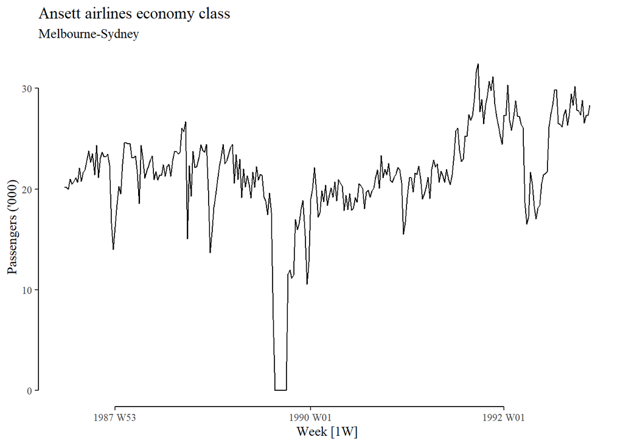

```r
# For svg: https://www.r-bloggers.com/2020/05/superior-svg-graphics-rendering-in-r-and-why-it-matters/ # nolint
autoplot(melsyd_economy, Passengers) +
  labs(
    title = "Ansett airlines economy class",
    subtitle = "Melbourne-Sydney",
    y = "Passengers ('000)"
  ) + short_axis()
```

## Seasonal plots

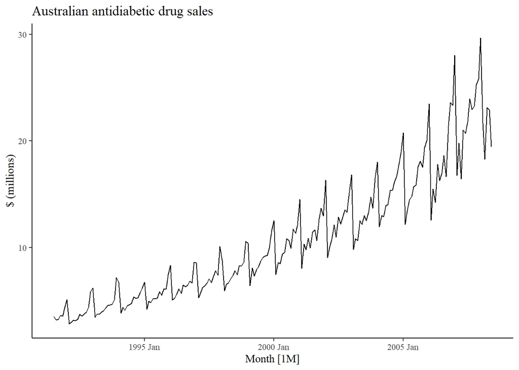

```r
autoplot(a10, TotalCost) +
  labs(
    y = "$ (millions)",
    title = "Australian antidiabetic drug sales"
  )
```

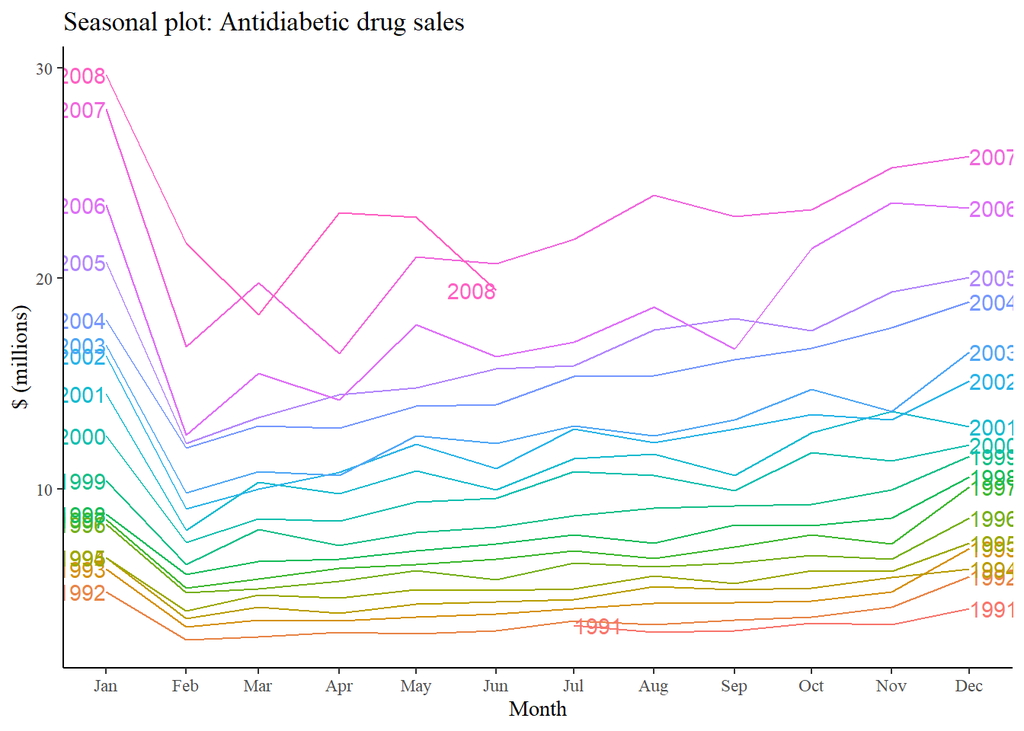

```r
a10 %>%
  gg_season(TotalCost, labels = "both") +
  labs(y = "$ (millions)",
       title = "Seasonal plot: Antidiabetic drug sales")
```

### Electricity demand graphs

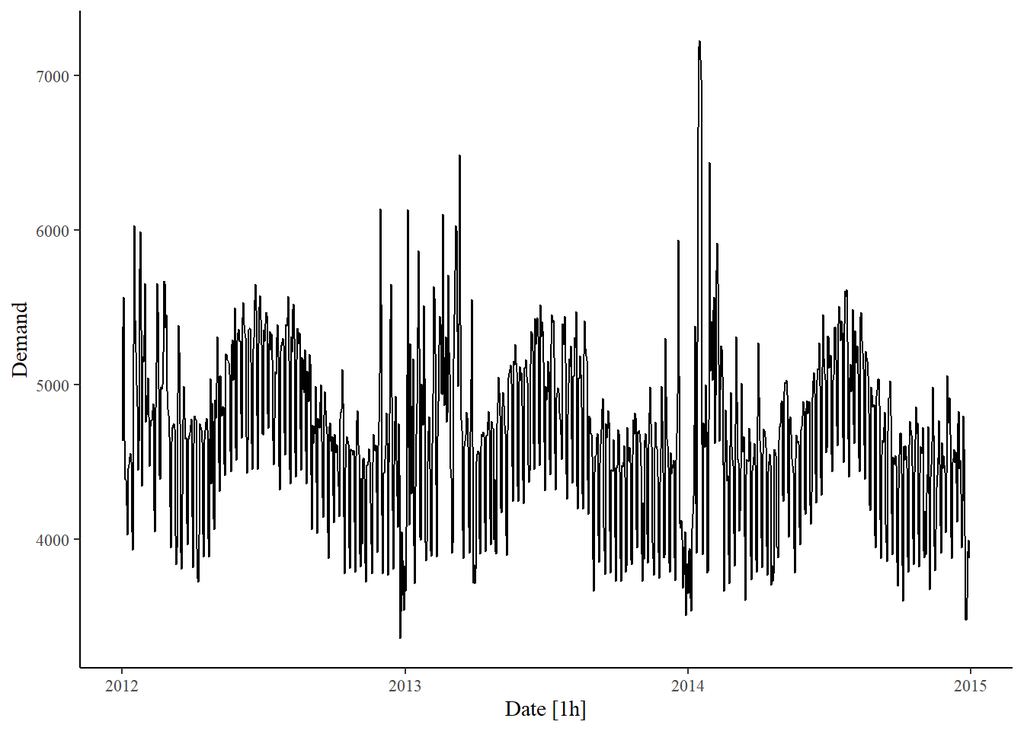

```r
as_tibble(vic_elec) %>%
  group_by(Date = floor_date(Time, "day")) %>%
  summarise(
    Demand = mean(Demand),
    Temperature = mean(Temperature)
  ) %>%
  as_tsibble(index = Date) %>%
  autoplot(Demand)
```

There is a peak at +7000MW at the beginning of 2014. Curious.

```r
as_tibble(vic_elec) %>%
  group_by(Date = floor_date(Time, "day")) %>%
  summarise(
    Demand = mean(Demand),
    Temperature = mean(Temperature)
  ) %>%
  filter(Demand > 6500)
```

```
## # A tibble: 4 x 3
##   Date                Demand Temperature
##   <dttm>               <dbl>       <dbl>
## 1 2014-01-14 00:00:00  6665.        32.1
## 2 2014-01-15 00:00:00  7183.        33.9
## 3 2014-01-16 00:00:00  7223.        33.9
## 4 2014-01-17 00:00:00  6976.        31.6
```

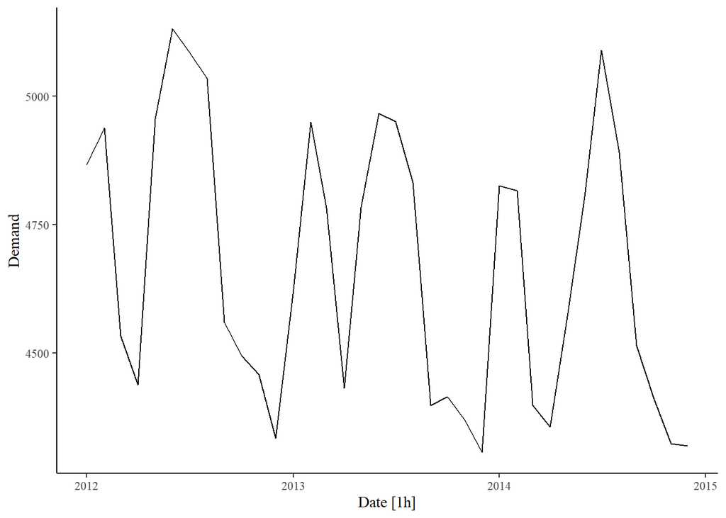

```r
as_tibble(vic_elec) %>%
  group_by(Date = floor_date(Time, "month")) %>%
  summarise(Demand = mean(Demand)) %>%
  as_tsibble(index = Date) %>%
  autoplot(Demand)
```

Seasonal plots

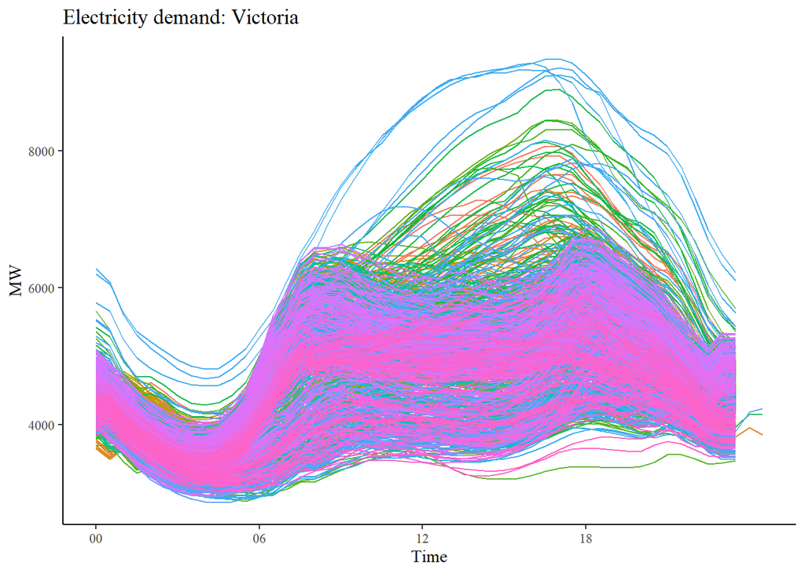

```r
vic_elec %>% gg_season(Demand, period = "day") +
  theme(legend.position = "none") +
  labs(y = "MW", title = "Electricity demand: Victoria")
```

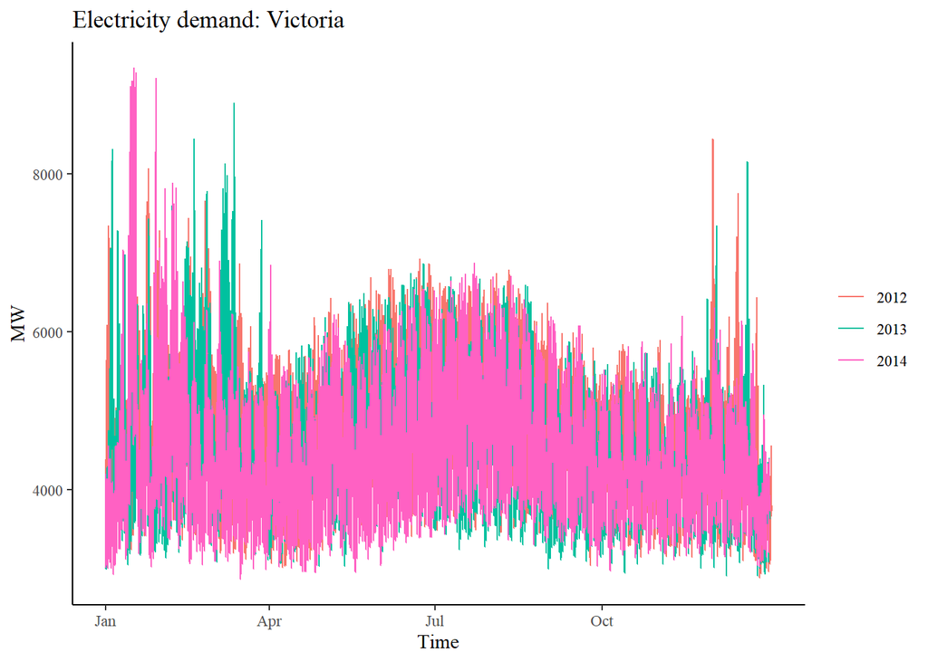

```r
vic_elec %>% gg_season(Demand, period = "year") +
  labs(y = "MW", title = "Electricity demand: Victoria")
```

## Seasonal subseries plots

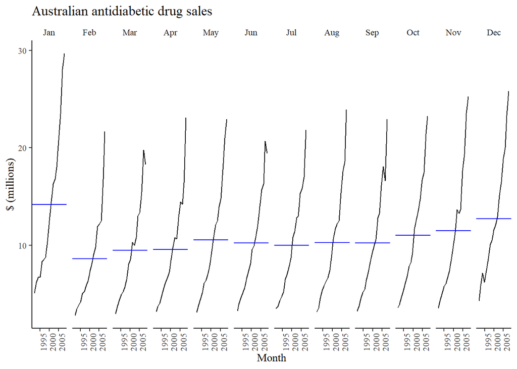

```r
a10 %>%
  gg_subseries(TotalCost) +
  labs(
    y = "$ (millions)",
    title = "Australian antidiabetic drug sales"
  )
```

```r
holidays <- tourism %>%
  filter(Purpose == "Holiday") %>%
  group_by(State) %>%
  summarise(Trips = sum(Trips))
holidays
```

```
## # A tsibble: 640 x 3 [1Q]
## # Key:       State [8]
##    State Quarter Trips
##    <chr>   <qtr> <dbl>
##  1 ACT   1998 Q1  196.
##  2 ACT   1998 Q2  127.
##  3 ACT   1998 Q3  111.
##  4 ACT   1998 Q4  170.
##  5 ACT   1999 Q1  108.
##  6 ACT   1999 Q2  125.
##  7 ACT   1999 Q3  178.
##  8 ACT   1999 Q4  218.
##  9 ACT   2000 Q1  158.
## 10 ACT   2000 Q2  155.
## # ... with 630 more rows
```

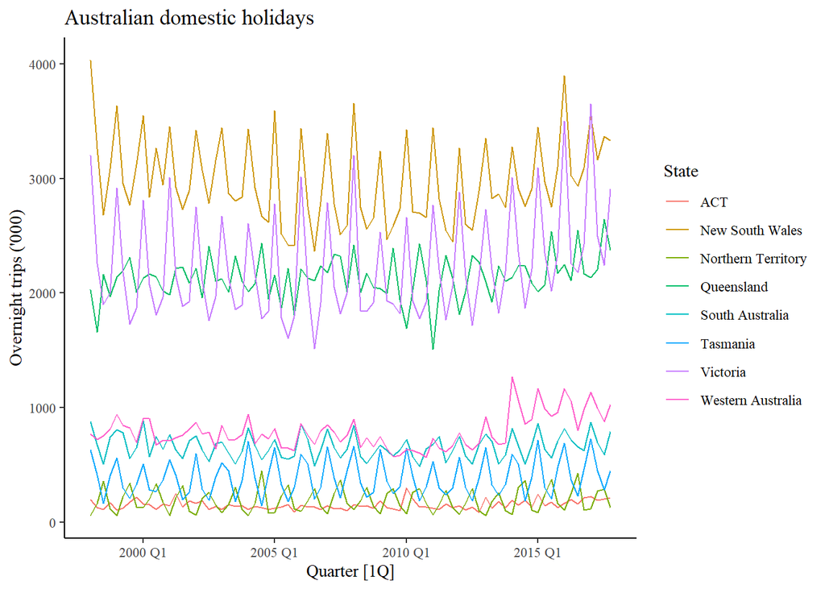

```r
autoplot(holidays, Trips) +
  labs(y = "Overnight trips ('000)",
       title = "Australian domestic holidays")
```

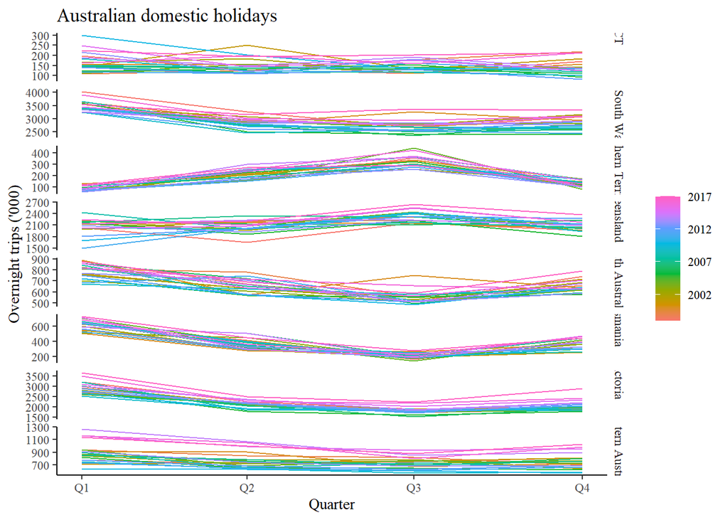

```r
gg_season(holidays, Trips) +
  labs(y = "Overnight trips ('000)",
       title = "Australian domestic holidays")
```

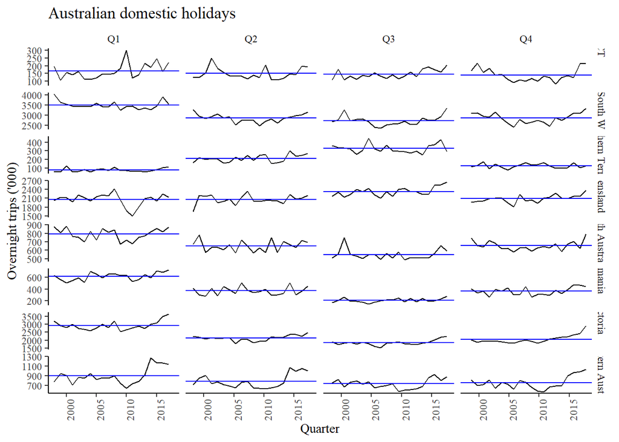

```r
holidays %>%
  gg_subseries(Trips) +
  labs(y = "Overnight trips ('000)",
       title = "Australian domestic holidays")
```

## Scatterplots

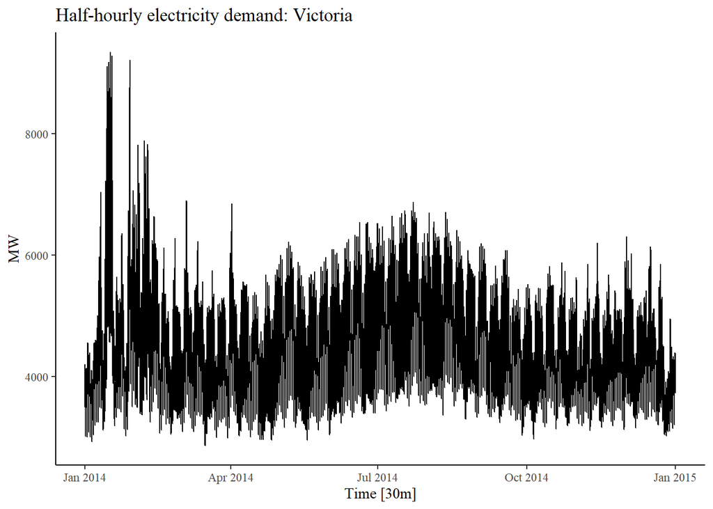

```r
vic_elec %>%
  filter(year(Time) == 2014) %>%
  autoplot(Demand) +
  labs(y = "MW",
       title = "Half-hourly electricity demand: Victoria")
```

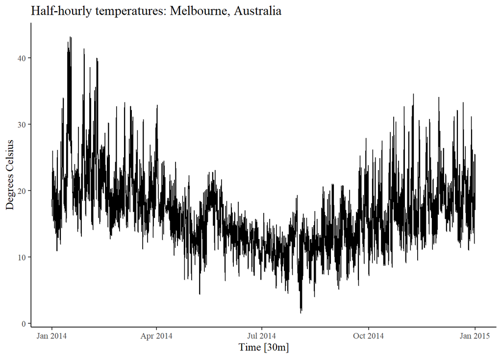

```r
vic_elec %>%
  filter(year(Time) == 2014) %>%
  autoplot(Temperature) +
  labs(
    y = "Degrees Celsius",
    title = "Half-hourly temperatures: Melbourne, Australia"
  )
```

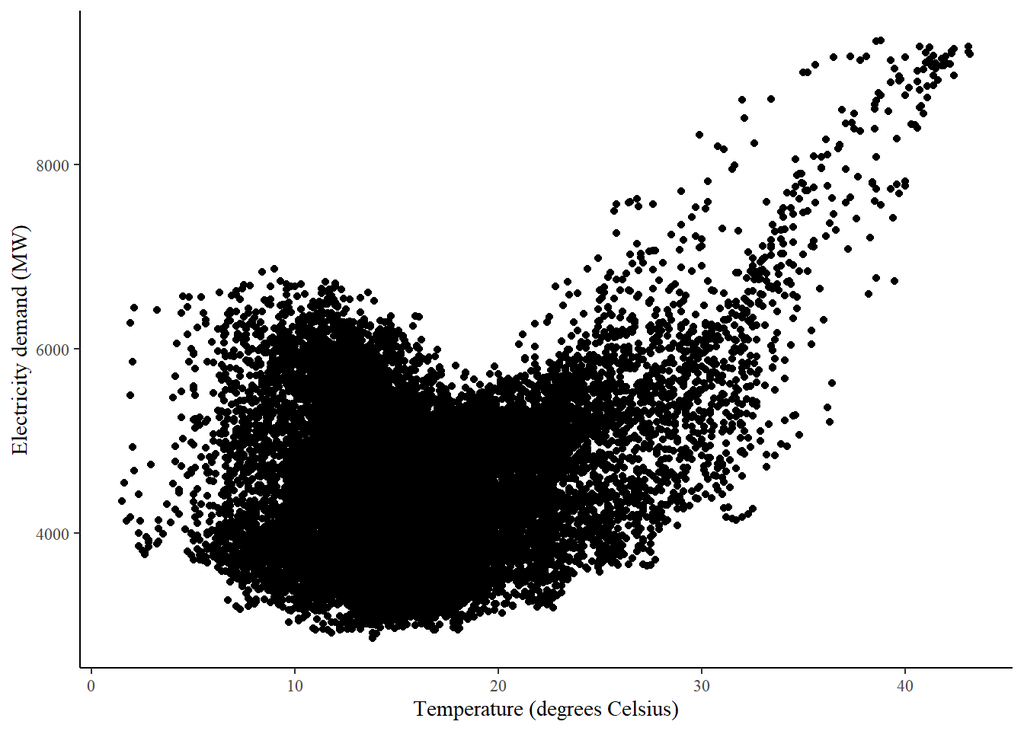

```r
vic_elec %>%
  filter(year(Time) == 2014) %>%
  ggplot(aes(x = Temperature, y = Demand)) +
  geom_point() +
  labs(x = "Temperature (degrees Celsius)",
       y = "Electricity demand (MW)")
```

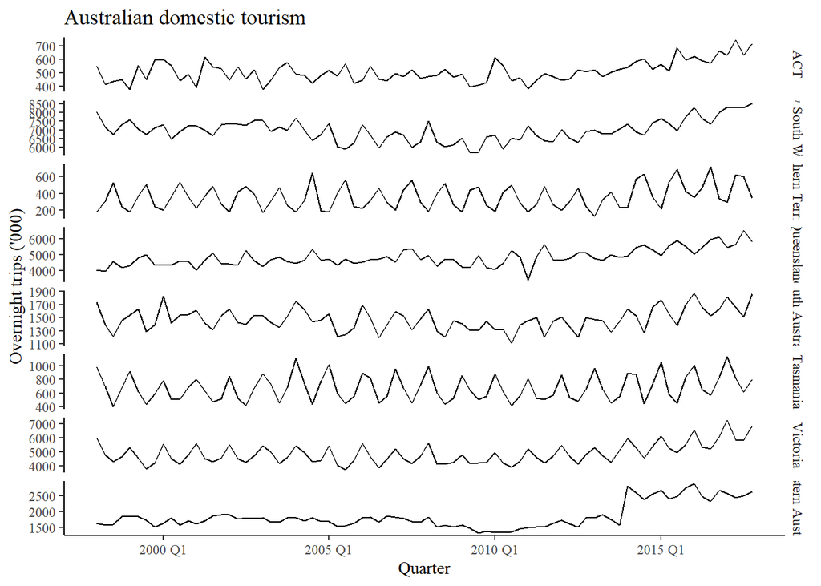

```r
visitors <- tourism %>%
  group_by(State) %>%
  summarise(Trips = sum(Trips))
visitors %>%
  ggplot(aes(x = Quarter, y = Trips)) +
  geom_line() +
  facet_grid(vars(State), scales = "free_y") +
  labs(title = "Australian domestic tourism",
       y = "Overnight trips ('000)")
```

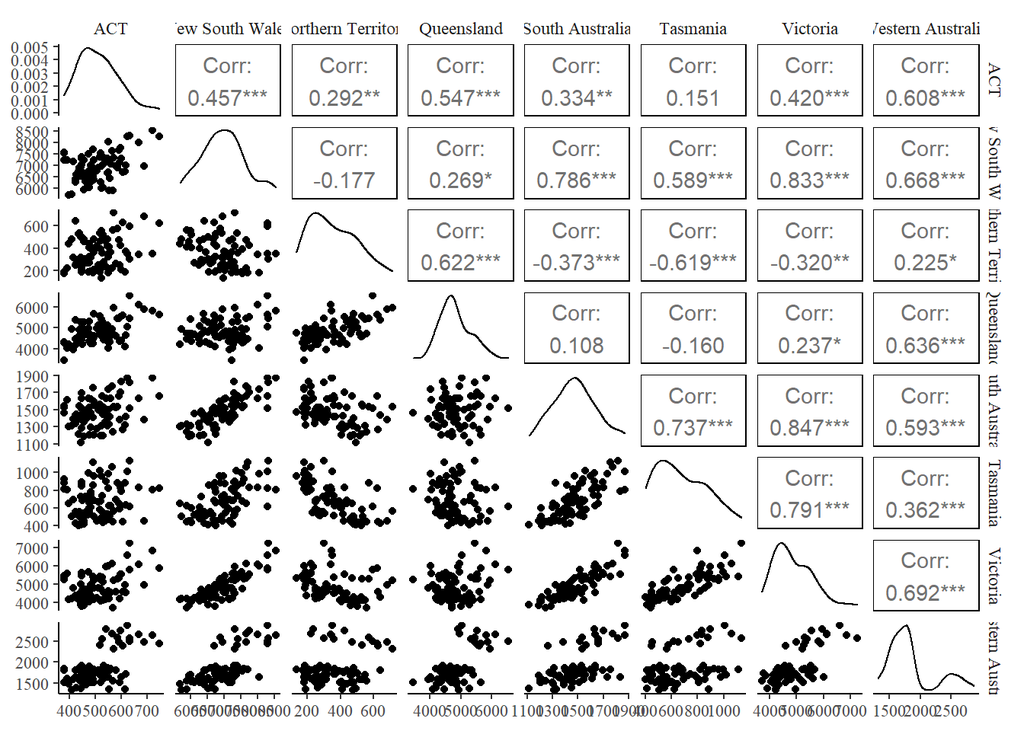

```r
visitors %>%
  pivot_wider(values_from = Trips, names_from = State) %>%
  GGally::ggpairs(columns = 2:9)
```

## Lag plots

```r
aus_production
```

```
## # A tsibble: 218 x 7 [1Q]
##    Quarter  Beer Tobacco Bricks Cement Electricity   Gas
##      <qtr> <dbl>   <dbl>  <dbl>  <dbl>       <dbl> <dbl>
##  1 1956 Q1   284    5225    189    465        3923     5
##  2 1956 Q2   213    5178    204    532        4436     6
##  3 1956 Q3   227    5297    208    561        4806     7
##  4 1956 Q4   308    5681    197    570        4418     6
##  5 1957 Q1   262    5577    187    529        4339     5
##  6 1957 Q2   228    5651    214    604        4811     7
##  7 1957 Q3   236    5317    227    603        5259     7
##  8 1957 Q4   320    6152    222    582        4735     6
##  9 1958 Q1   272    5758    199    554        4608     5
## 10 1958 Q2   233    5641    229    620        5196     7
## # ... with 208 more rows
```

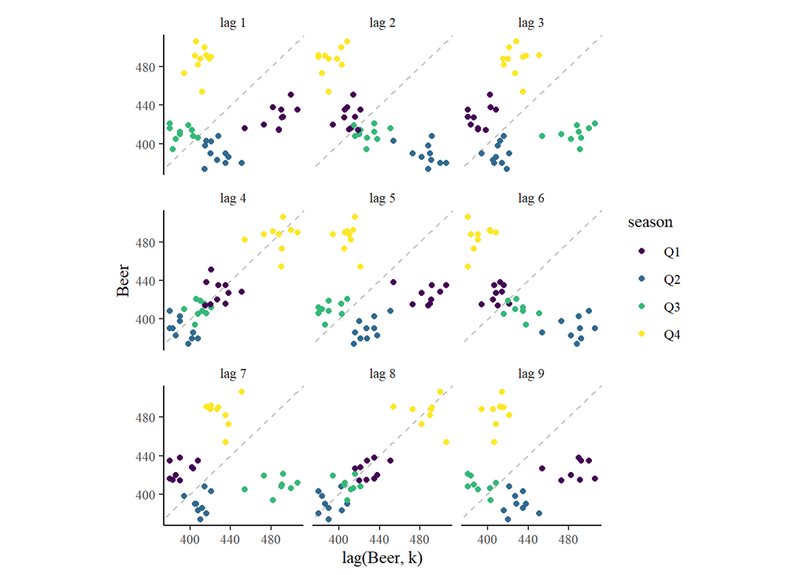

```r
recent_production <- aus_production %>%
  filter(year(Quarter) >= 2000)
recent_production %>%
  gg_lag(Beer, geom = "point") +
  labs(x = "lag(Beer, k)")
```

## Autocorrelation

```r
recent_production %>% ACF(Beer, lag_max = 9)
```

```
## # A tsibble: 9 x 2 [1Q]
##     lag      acf
##   <lag>    <dbl>
## 1    1Q -0.0530
## 2    2Q -0.758
## 3    3Q -0.0262
## 4    4Q  0.802
## 5    5Q -0.0775
## 6    6Q -0.657
## 7    7Q  0.00119
## 8    8Q  0.707
## 9    9Q -0.0888
```

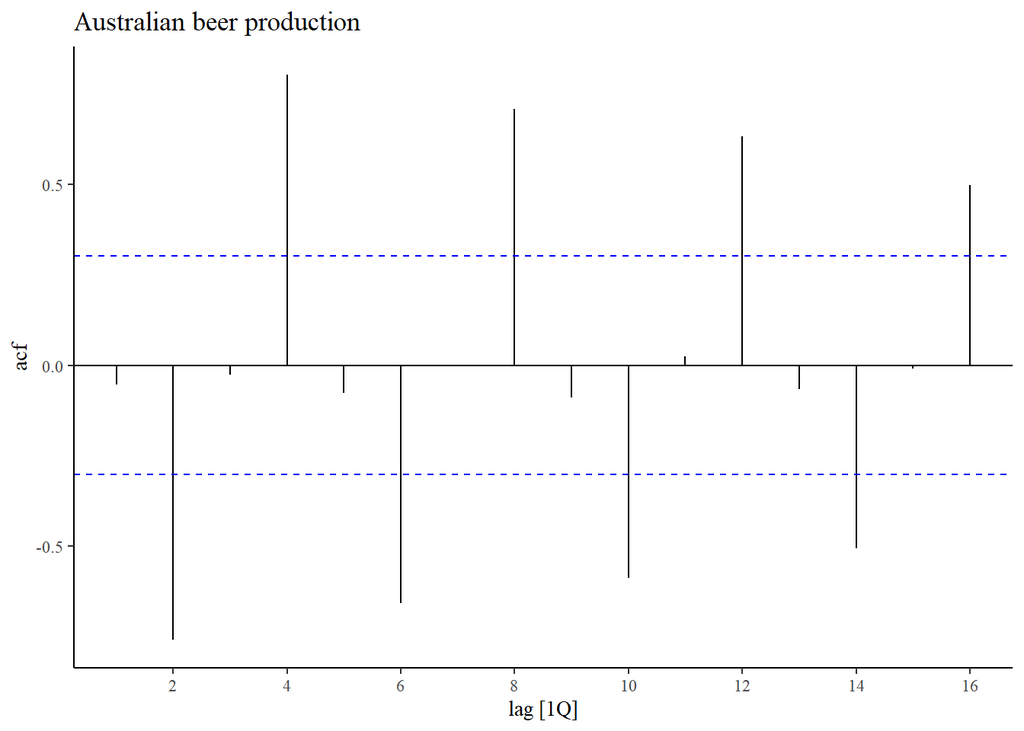

```r
recent_production %>%
  ACF(Beer) %>%
  autoplot() + labs(title = "Australian beer production")
```

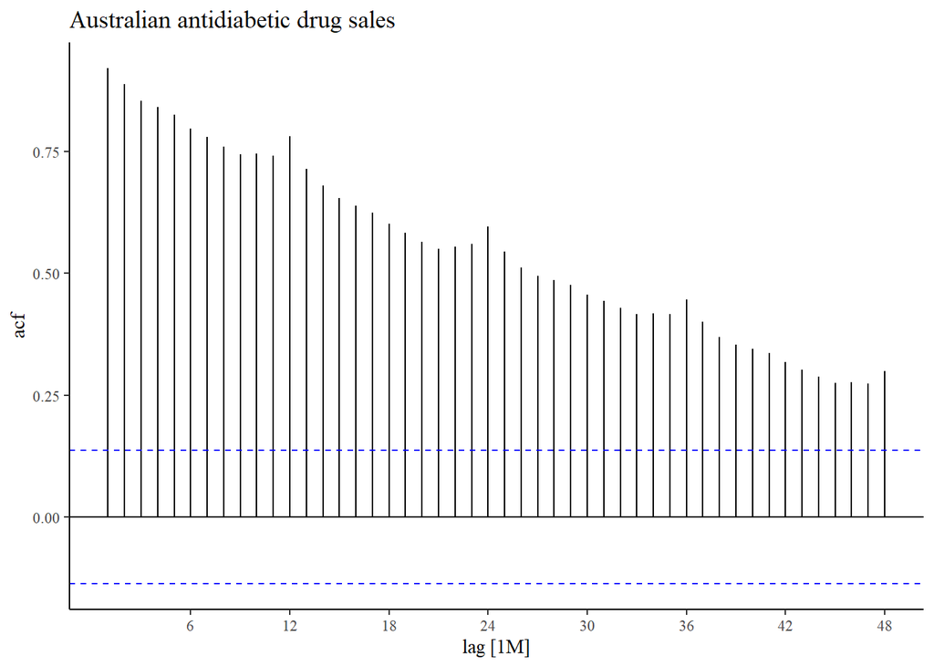

```r
a10 %>%
  ACF(TotalCost, lag_max = 48) %>%
  autoplot() +
  labs(title = "Australian antidiabetic drug sales")
```

## White noise

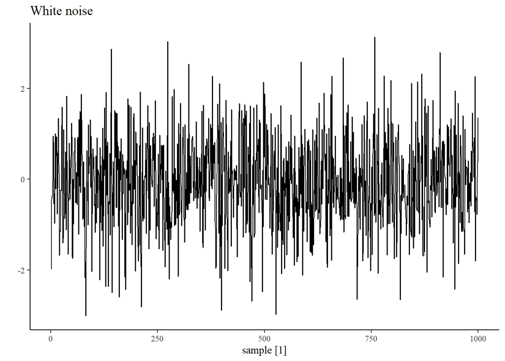

```r
y <- tsibble(sample = 1:1000, wn = rnorm(1000), index = sample)
y %>% autoplot(wn) + labs(title = "White noise", y = "")
```

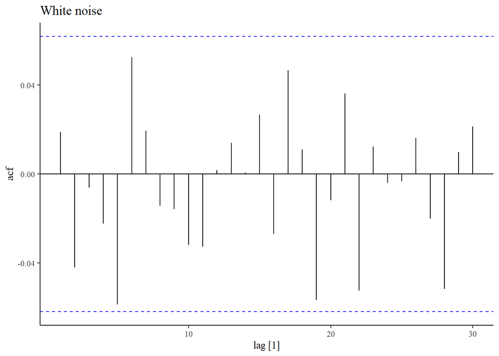

```r
y %>%
  ACF(wn) %>%
  autoplot() + labs(title = "White noise")
```

## Exercises

1. Use the help function to explore what the series gafa_stock, PBS, vic_elec and pelt represent.
1. use autoplot() to find what days corresponded to the peak closing price for each of the four stocks in gafa_stock
2. What is the time interval of each series

`gafa_stock`

Daily data. Except week-ends.

```r
gafa_stock
```

```
## # A tsibble: 5,032 x 8 [!]
## # Key:       Symbol [4]
##    Symbol Date        Open  High   Low Close Adj_Close    Volume
##    <chr>  <date>     <dbl> <dbl> <dbl> <dbl>     <dbl>     <dbl>
##  1 AAPL   2014-01-02  79.4  79.6  78.9  79.0      67.0  58671200
##  2 AAPL   2014-01-03  79.0  79.1  77.2  77.3      65.5  98116900
##  3 AAPL   2014-01-06  76.8  78.1  76.2  77.7      65.9 103152700
##  4 AAPL   2014-01-07  77.8  78.0  76.8  77.1      65.4  79302300
##  5 AAPL   2014-01-08  77.0  77.9  77.0  77.6      65.8  64632400
##  6 AAPL   2014-01-09  78.1  78.1  76.5  76.6      65.0  69787200
##  7 AAPL   2014-01-10  77.1  77.3  75.9  76.1      64.5  76244000
##  8 AAPL   2014-01-13  75.7  77.5  75.7  76.5      64.9  94623200
##  9 AAPL   2014-01-14  76.9  78.1  76.8  78.1      66.1  83140400
## 10 AAPL   2014-01-15  79.1  80.0  78.8  79.6      67.5  97909700
## # ... with 5,022 more rows
```

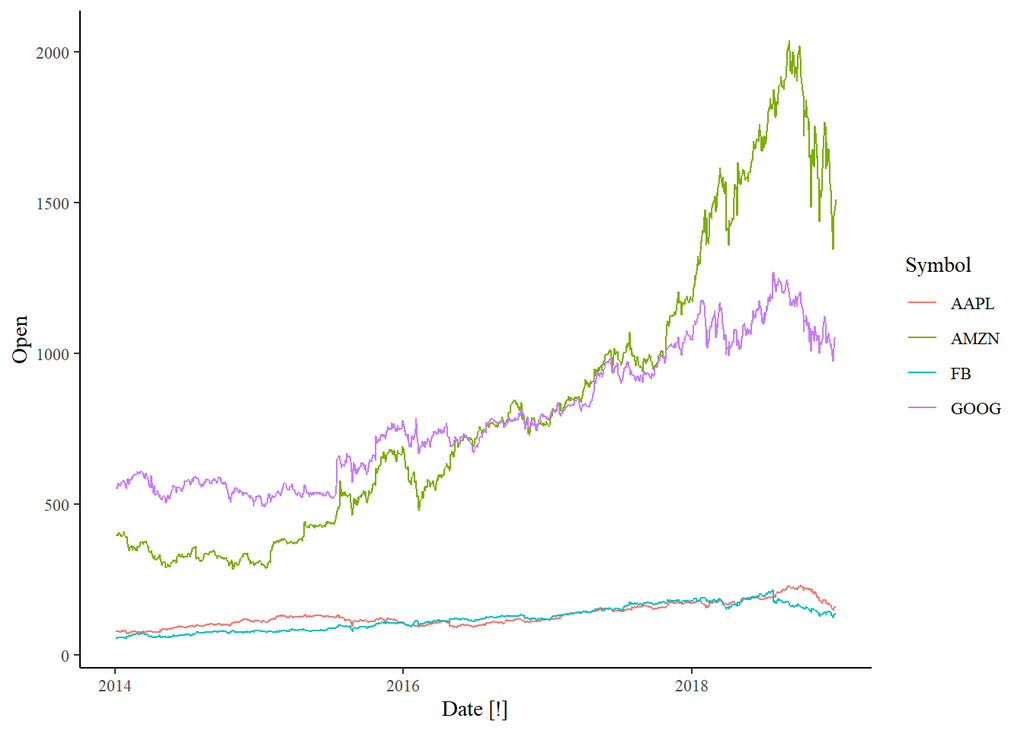

```r
gafa_stock %>%
  autoplot(Open)
```

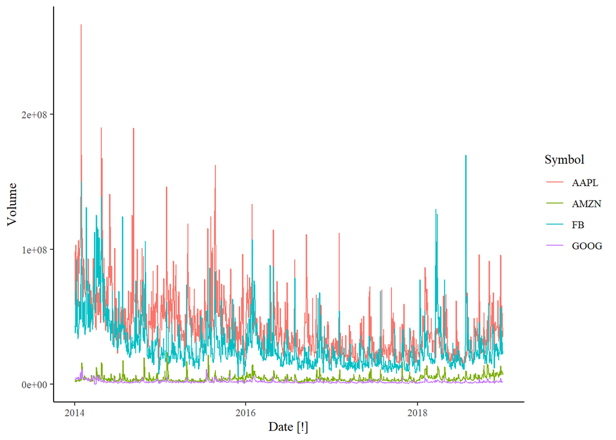

```r
gafa_stock %>%
  autoplot(Volume)
```

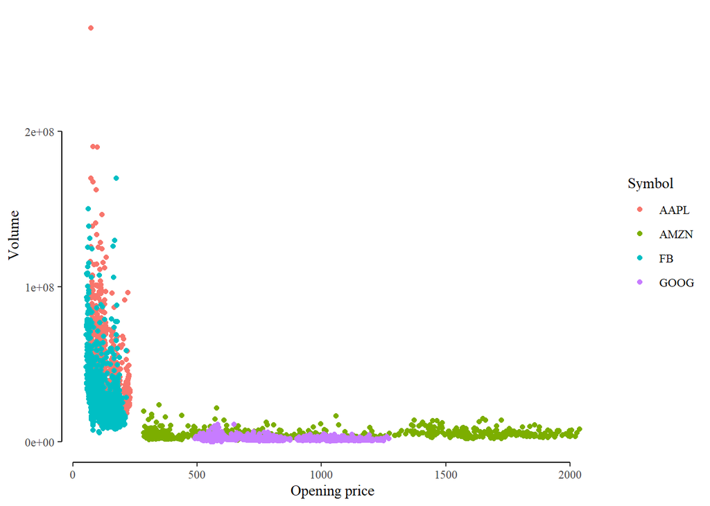

```r
gafa_stock %>%
  ggplot(
    aes(x = Open, y = Volume, color = Symbol)
  ) +
  geom_point() +
  labs(
    x = "Opening price",
    y = "Volume"
  ) +
  short_axis()
```

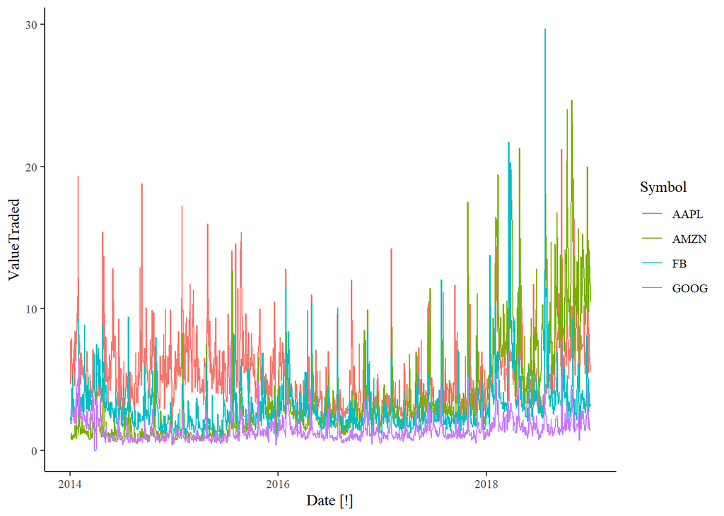

```r
gafa_stock %>%
  mutate(ValueTraded = Open * Volume / 1e9) %>%
  autoplot(ValueTraded)
```

Efficient solution to get maximum Close for each Symbol.

```r
as_tibble(gafa_stock) %>%
  group_by(Symbol) %>%
  filter(Close == max(Close)) %>%
  select(Symbol, Date, Close) %>%
  kable()
```

| Symbol | Date | Close |
| --- | --- | --- |
| AAPL | 2018-10-03 | 232.07 |
| AMZN | 2018-09-04 | 2039.51 |
| FB | 2018-07-25 | 217.50 |
| GOOG | 2018-07-26 | 1268.33 |

Inefficient solution

```r
for (company in factor(gafa_stock$Symbol) %>% levels()) {
  gafa_stock %>%
    filter(Symbol == company) %>%
    arrange(desc(Close)) %>%
    print()
}
```

```
## # A tsibble: 1,258 x 8 [!]
## # Key:       Symbol [1]
##    Symbol Date        Open  High   Low Close Adj_Close   Volume
##    <chr>  <date>     <dbl> <dbl> <dbl> <dbl>     <dbl>    <dbl>
##  1 AAPL   2018-10-03  230.  233.  230.  232.      230. 28654800
##  2 AAPL   2018-10-02  227.  230   227.  229.      228. 24788200
##  3 AAPL   2018-09-04  228.  229.  227.  228.      227. 27390100
##  4 AAPL   2018-10-04  231.  232.  227.  228.      226. 32042000
##  5 AAPL   2018-08-31  227.  229.  226   228.      226. 43340100
##  6 AAPL   2018-10-01  228.  229.  226.  227.      226. 23600800
##  7 AAPL   2018-09-05  229.  230.  225.  227.      225. 33333000
##  8 AAPL   2018-10-09  224.  227.  222.  227.      225. 26891000
##  9 AAPL   2018-09-13  224.  228.  223.  226.      225. 41706400
## 10 AAPL   2018-09-28  225.  226.  224.  226.      224. 22929400
## # ... with 1,248 more rows
```

```
## # A tsibble: 1,258 x 8 [!]
## # Key:       Symbol [1]
##    Symbol Date        Open  High   Low Close Adj_Close  Volume
##    <chr>  <date>     <dbl> <dbl> <dbl> <dbl>     <dbl>   <dbl>
##  1 AMZN   2018-09-04 2026. 2050. 2013  2040.     2040. 5721100
##  2 AMZN   2018-09-27 1993. 2016. 1989. 2013.     2013. 4329400
##  3 AMZN   2018-08-31 2007  2022. 2005. 2013.     2013. 4204400
##  4 AMZN   2018-10-01 2022. 2033. 2004. 2004.     2004. 3460500
##  5 AMZN   2018-09-28 2004. 2027. 1996. 2003      2003  4085100
##  6 AMZN   2018-08-30 1997. 2026. 1987. 2002.     2002. 7277300
##  7 AMZN   2018-08-29 1953. 1999. 1949. 1998.     1998. 6531800
##  8 AMZN   2018-09-05 2038. 2040. 1990. 1995.     1995. 8220600
##  9 AMZN   2018-09-12 1994  2000  1962. 1990      1990  4414000
## 10 AMZN   2018-09-13 2000  2009. 1982. 1990.     1990. 3621500
## # ... with 1,248 more rows
```

```
## # A tsibble: 1,258 x 8 [!]
## # Key:       Symbol [1]
##    Symbol Date        Open  High   Low Close Adj_Close   Volume
##    <chr>  <date>     <dbl> <dbl> <dbl> <dbl>     <dbl>    <dbl>
##  1 FB     2018-07-25  216.  219.  214.  218.      218. 58954200
##  2 FB     2018-07-24  215.  216.  213.  215.      215. 28468700
##  3 FB     2018-07-23  211.  212.  209.  211.      211. 16732000
##  4 FB     2018-07-17  205.  210.  205.  210.      210. 15349900
##  5 FB     2018-07-20  209.  212.  208.  210.      210. 16163900
##  6 FB     2018-07-18  210.  211.  208.  209.      209. 15334900
##  7 FB     2018-07-19  209.  210.  208.  208.      208. 11350400
##  8 FB     2018-07-13  208.  208.  206.  207.      207. 11486800
##  9 FB     2018-07-16  208.  209.  207.  207.      207. 11078200
## 10 FB     2018-07-12  203.  207.  203.  207.      207. 15454700
## # ... with 1,248 more rows
```

```
## # A tsibble: 1,258 x 8 [!]
## # Key:       Symbol [1]
##    Symbol Date        Open  High   Low Close Adj_Close  Volume
##    <chr>  <date>     <dbl> <dbl> <dbl> <dbl>     <dbl>   <dbl>
##  1 GOOG   2018-07-26 1251  1270. 1249. 1268.     1268. 2405600
##  2 GOOG   2018-07-25 1239. 1266. 1239. 1264.     1264. 2127800
##  3 GOOG   2018-08-29 1237. 1251. 1236. 1249.     1249. 1298900
##  4 GOOG   2018-08-09 1250. 1256. 1246. 1249.     1249.  841800
##  5 GOOG   2018-07-24 1263. 1266  1236. 1248.     1248. 3318200
##  6 GOOG   2018-08-08 1240. 1256. 1238. 1246.     1246. 1370300
##  7 GOOG   2018-08-07 1237  1251. 1236. 1242.     1242. 1494000
##  8 GOOG   2018-08-14 1235. 1246. 1225. 1242.     1242. 1348100
##  9 GOOG   2018-08-27 1228. 1243. 1226. 1242.     1242. 1156300
## 10 GOOG   2018-08-30 1244. 1254. 1233. 1239.     1239. 1331400
## # ... with 1,248 more rows
```

3. Download the file tute1.csv from the book website, open it in Excel (or some other spreadsheet application), and review its contents. You should find four columns of information. Columns B through D each contain a quarterly series, labelled Sales, AdBudget and GDP. Sales contains the quarterly sales for a small company over the period 1981-2005. AdBudget is the advertising budget and GDP is the gross domestic product. All series have been adjusted for inflation.

```r
tute1 <- readr::read_csv("tute1.csv") %>%
  mutate(Quarter = yearmonth(Quarter)) %>%
  as_tsibble(index = Quarter)
tute1
```

```
## # A tsibble: 100 x 4 [3M]
##     Quarter Sales AdBudget   GDP
##       <mth> <dbl>    <dbl> <dbl>
##  1 1981 Mar 1020.     659.  252.
##  2 1981 Jun  889.     589   291.
##  3 1981 Sep  795      512.  291.
##  4 1981 Dec 1004.     614.  292.
##  5 1982 Mar 1058.     647.  279.
##  6 1982 Jun  944.     602   254
##  7 1982 Sep  778.     531.  296.
##  8 1982 Dec  932.     608.  272.
##  9 1983 Mar  996.     638.  260.
## 10 1983 Jun  908.     582.  280.
## # ... with 90 more rows
```

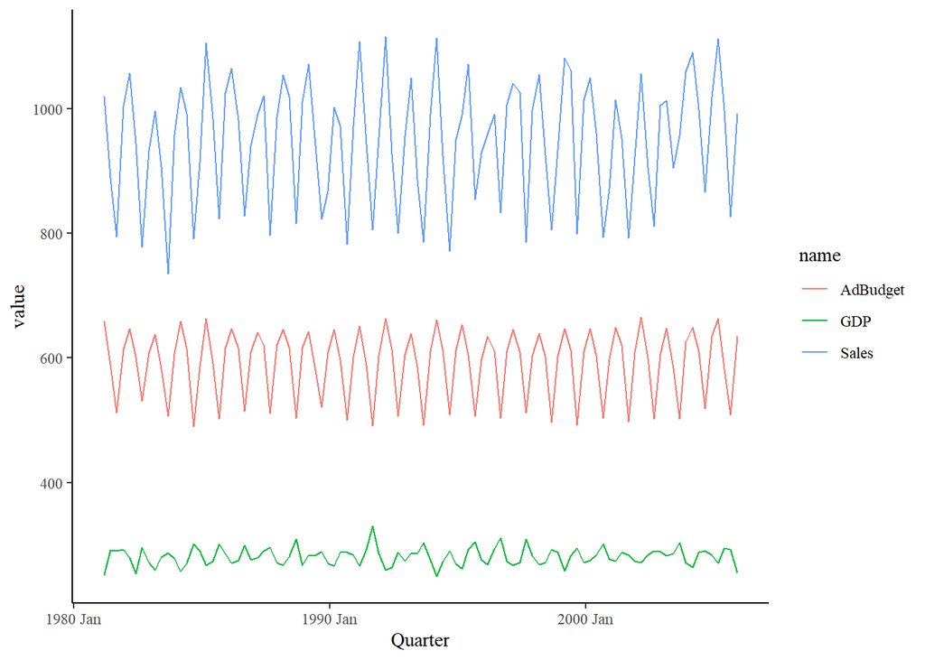

```r
tute1 %>%
  pivot_longer(!Quarter) %>%
  ggplot(
    aes(x = Quarter, y = value, color = name)
  ) +
  geom_line()
```

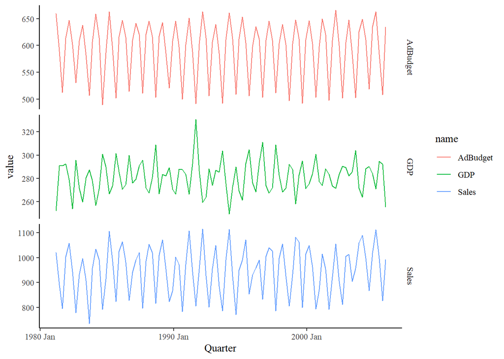

```r
tute1 %>%
  pivot_longer(!Quarter) %>%
  ggplot(
    aes(x = Quarter, y = value, color = name)
  ) +
  geom_line() +
  facet_grid(name ~ ., scales = "free_y")
```

4. `USgas`

```r
us_total <- USgas::us_total %>%
  as_tsibble(index = year, key = state)
```

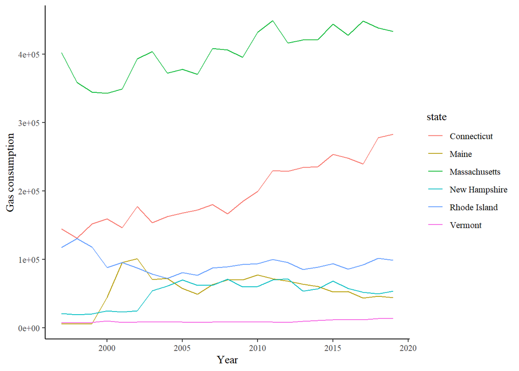

```r
new_england <- c(
  "Maine", "Vermont", "New Hampshire", "Massachusetts",
  "Connecticut", "Rhode Island"
)

us_total %>%
  filter(state %in% new_england) %>%
  ggplot(
    aes(x = year, y = y, color = state)
  ) +
  geom_line() +
  labs(x = "Year", y = "Gas consumption")
```

5. Tourism.xlsx

```r
tourism_xl <- readxl::read_excel("tourism.xlsx") %>%
  mutate(Quarter = yearquarter(Quarter)) %>%
  as_tsibble(index = Quarter, key = c("Region", "State", "Purpose"))
```

```r
tourism_xl %>%
  group_by(Region, Purpose) %>%
  summarise(Trips = mean(Trips)) %>%
  arrange(desc(Trips))
```

```
## # A tsibble: 24,320 x 4 [1Q]
## # Key:       Region, Purpose [304]
## # Groups:    Region [76]
##    Region          Purpose  Quarter Trips
##    <chr>           <chr>      <qtr> <dbl>
##  1 Melbourne       Visiting 2017 Q4  985.
##  2 Sydney          Business 2001 Q4  948.
##  3 Sydney          Visiting 2016 Q4  921.
##  4 Sydney          Visiting 2017 Q4  920.
##  5 Sydney          Visiting 2017 Q1  916.
##  6 South Coast     Holiday  1998 Q1  915.
##  7 North Coast NSW Holiday  2016 Q1  906.
##  8 Sydney          Business 2017 Q3  892.
##  9 Sydney          Business 2017 Q2  884.
## 10 Sydney          Visiting 2013 Q4  882.
## # ... with 24,310 more rows
```

```r
tourism_xl %>%
  group_by(State) %>%
  summarise(Trips = sum(Trips))
```

```
## # A tsibble: 640 x 3 [1Q]
## # Key:       State [8]
##    State Quarter Trips
##    <chr>   <qtr> <dbl>
##  1 ACT   1998 Q1  551.
##  2 ACT   1998 Q2  416.
##  3 ACT   1998 Q3  436.
##  4 ACT   1998 Q4  450.
##  5 ACT   1999 Q1  379.
##  6 ACT   1999 Q2  558.
##  7 ACT   1999 Q3  449.
##  8 ACT   1999 Q4  595.
##  9 ACT   2000 Q1  600.
## 10 ACT   2000 Q2  557.
## # ... with 630 more rows
```

6. Trivial. I have done that too much already.
7. `aus_arrivals`

```r
aus_arrivals
```

```
## # A tsibble: 508 x 3 [1Q]
## # Key:       Origin [4]
##    Quarter Origin Arrivals
##      <qtr> <chr>     <int>
##  1 1981 Q1 Japan     14763
##  2 1981 Q2 Japan      9321
##  3 1981 Q3 Japan     10166
##  4 1981 Q4 Japan     19509
##  5 1982 Q1 Japan     17117
##  6 1982 Q2 Japan     10617
##  7 1982 Q3 Japan     11737
##  8 1982 Q4 Japan     20961
##  9 1983 Q1 Japan     20671
## 10 1983 Q2 Japan     12235
## # ... with 498 more rows
```

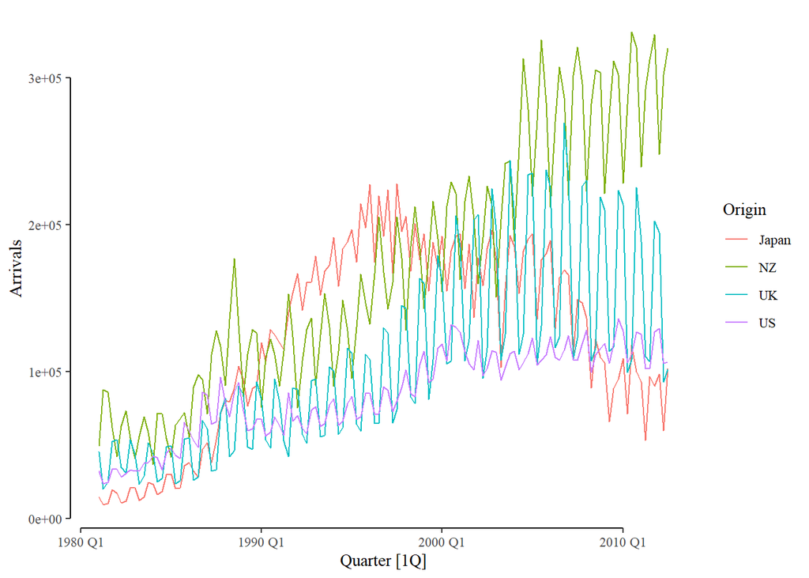

```r
aus_arrivals %>%
  autoplot(Arrivals) +
  short_axis()
```

The magnitude of the seasonality is a lot higher for NZ and the UK. Less so for Japan and the US. All countries seem to follow an increasing trend, except for flights coming from Japan: it peaked in the mid 90s, and has decreased steadily ever since.

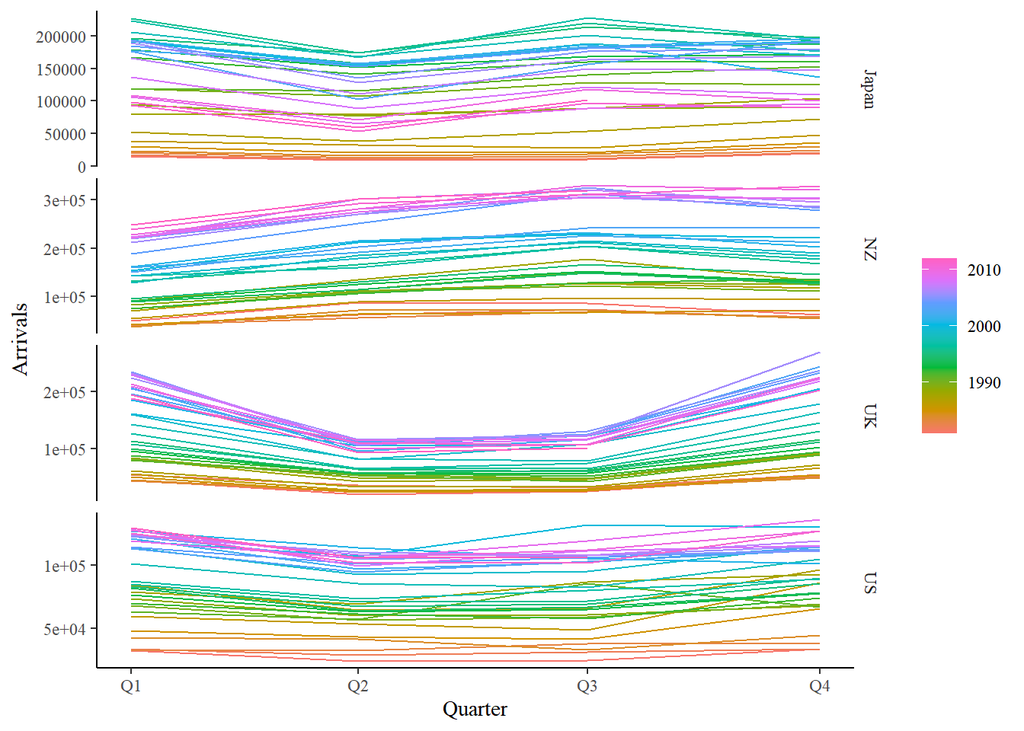

```r
aus_arrivals %>%
  gg_season(y = Arrivals)
```

Arrivals from the UK (and the US?) are noticeably higher in Q1 and Q4. Understandable, since it’s winter in the northern hemisphere. For NZ, we observe the opposite.

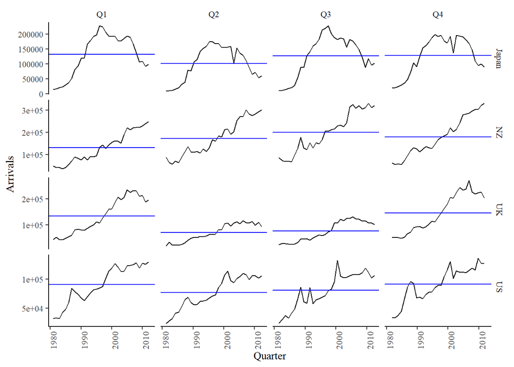

```r
aus_arrivals %>%
  gg_subseries(y = Arrivals)
```

It seems arrivals from the UK actually began decreasing a few years ago.  
There are some peaks in arrivals from the US at the end of the 80s and the 90s.